# Causal Inference

Dr. Lucy D’Agostino McGowan

## What is Causal Inference?

**Statistics tells us:** Variables are associated

**Causal inference asks:** Does changing one variable *cause* changes in another?

Moving from “X is correlated with Y” to “X causes Y”

# Causal DAGs

## What is a DAG?

**DAG: Directed Acyclic Graph**

A visual tool for representing our assumptions about the data generating mechanism

## A Simple DAG

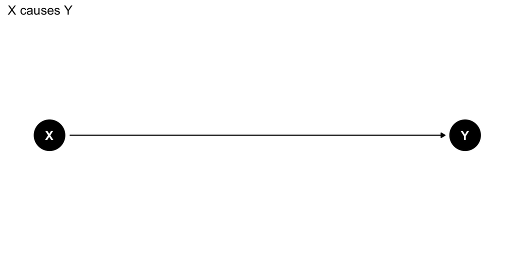

This DAG says: **X has a causal effect on Y**

## Example

**Example:** Ice cream sales and drowning deaths are correlated

Does ice cream cause drowning?

**No!** Temperature causes both:

**DAGs help us think clearly about what causes what**

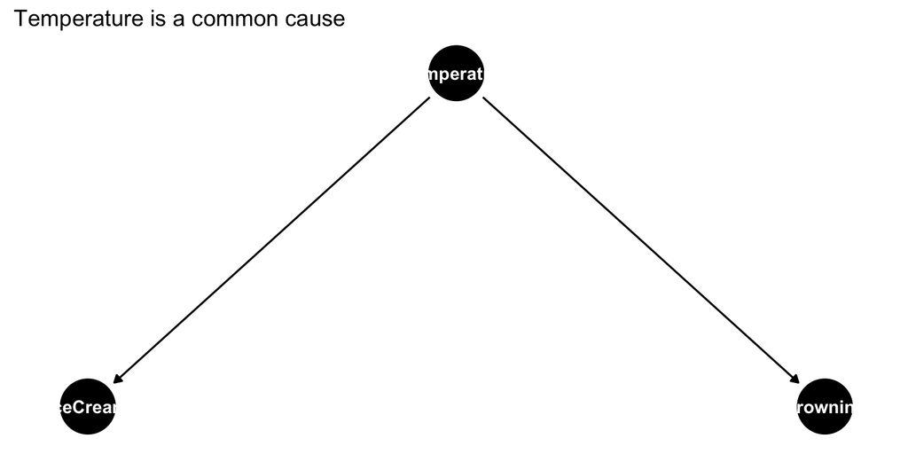

# The Fundamental Problem of Causal Inference

## Potential Outcomes

For each person $i$, there are two *potential outcomes*:

- $Y_i(1)$ = outcome if person $i$ receives an exposure
- $Y_i(0)$ = outcome if person $i$ does not receive exposure

**Individual treatment effect:**
$$\tau_i = Y_i(1) - Y_i(0)$$

## The Fundamental Problem

**We can only observe ONE potential outcome for each person!**

If person $i$ gets exposed, we see $Y_i(1)$ but not $Y_i(0)$

If person $i$ doesn’t get exposed, we see $Y_i(0)$ but not $Y_i(1)$

**The missing outcome is called the counterfactual**

## Average Treatment Effect (ATE)

Since we can’t measure individual effects, we focus on **averages**:

$$\text{ATE} = E[Y(1) - Y(0)] = E[Y(1)] - E[Y(0)]$$

**In words:** The average difference in outcomes if everyone was exposed vs. if no one was exposed

## Naive Comparison Doesn’t Work

**Tempting approach:** Compare exposed vs. unexposed groups
$$E[Y|X=1] - E[Y|X=0]$$

**Problem:** This is often NOT the same as the ATE because exposed and unexposed groups might differ in other ways

## Example: The Drug Study

Imagine a drug study where:

- Older people are more likely to receive the drug
- Older people tend to have worse health outcomes
- The drug actually helps (true effect = +10 points)

```r
# Naive comparison
naive_estimate <- mean(data$outcome[data$treatment == 1]) -
                  mean(data$outcome[data$treatment == 0])
naive_estimate
```

```
[1] 5.212386
```

**The naive estimate is wrong!** It’s confounded by age

# Confounders

## What is a Confounder?

A **confounder** is a variable that:

1. Affects the treatment/exposure
2. Affects the outcome
3. Is not caused by the treatment

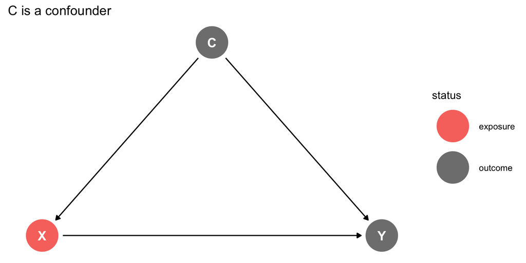

## Why Confounders Matter

Confounders create **spurious associations**

The correlation between X and Y is not purely causal, some of it is due to C

**Solution:** We need to “control for” or “adjust for” the confounder

## Multiple Confounders

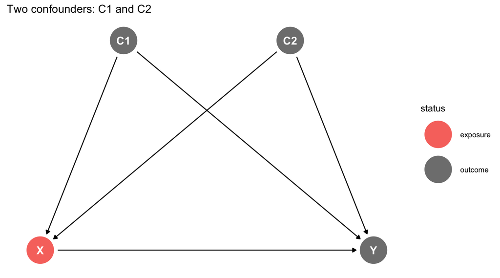

Real problems often have multiple confounders

We need to adjust for **all** of them to get the causal effect

# Colliders

## What is a Collider?

A **collider** is a variable that is caused by two other variables

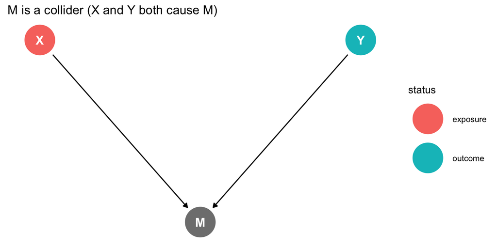

**Key point:** Arrows point **into** the collider

## Why Colliders Are Dangerous

**Do NOT control for colliders!**

Controlling for a collider creates a spurious association between its causes

This is called **collider bias** or **selection bias**

## Example: The Talent Paradox

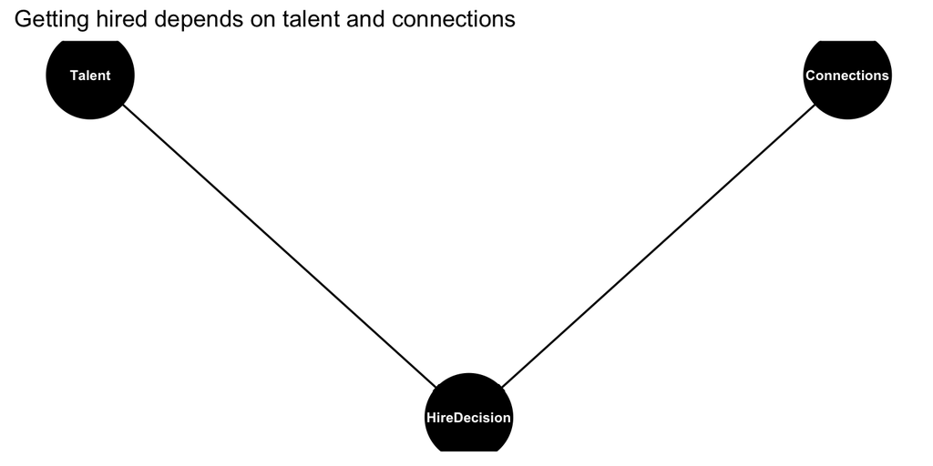

Among people who were hired (conditioning on the collider):

- High talent people may have fewer connections
- Low talent people may have more connections
- This creates a negative correlation that doesn’t exist in the full population!

## Visualizing Collider Bias

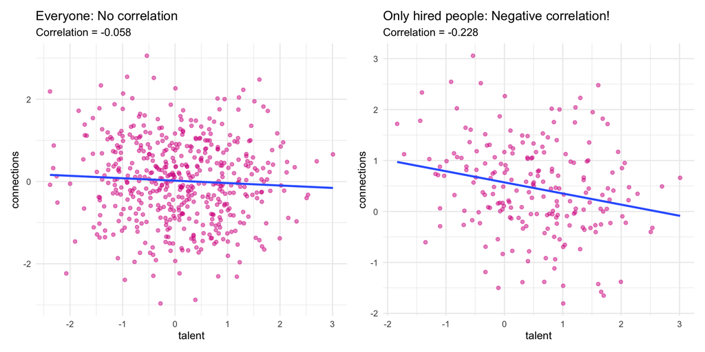

**This is collider bias in action!**

## Confounder vs. Collider

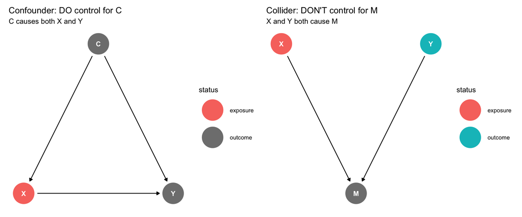

**Rule of thumb:**

- Arrows out → confounder → control for it
- Arrows in → collider → don’t control for it

# Paths and Backdoor Paths

## Paths in a DAG

A **path** is any route from X to Y following the arrows (in any direction)

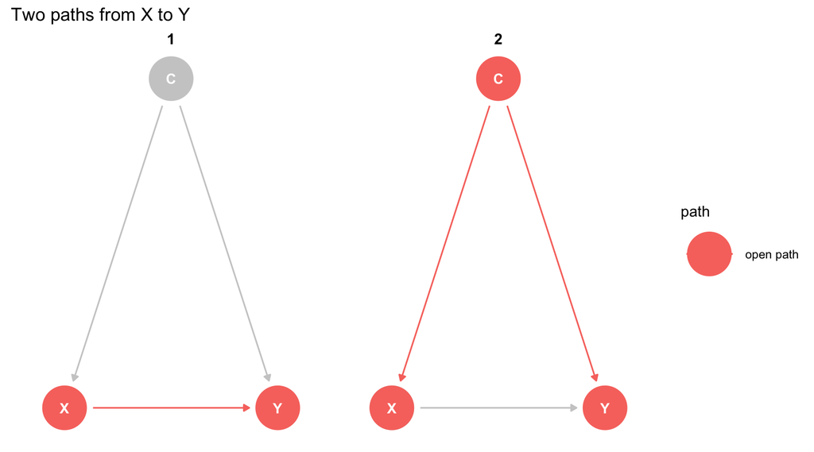

**Path 1:** X → Y (direct causal path)

**Path 2:** X ← C → Y (path through confounder)

## Open vs. Closed Paths

**Open path:** Association can flow through it

**Closed path:** Association is blocked

**A path is closed if:**

1. There’s a collider on the path (and we don’t condition on it), OR
2. We condition on a non-collider on the path

## Backdoor Paths

A **backdoor path** is a path from X to Y that starts with an arrow *into* X

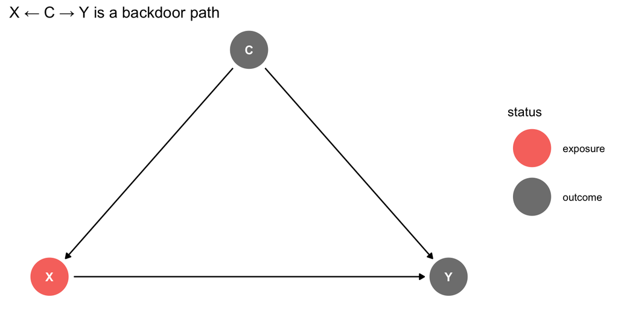

## Why Backdoor Paths Matter

**Goal of causal inference:** Isolate the causal effect of X on Y

**Problem:** Open backdoor paths allow non-causal association to flow

**Solution:** Close all backdoor paths by conditioning on the right variables

## Finding All Paths

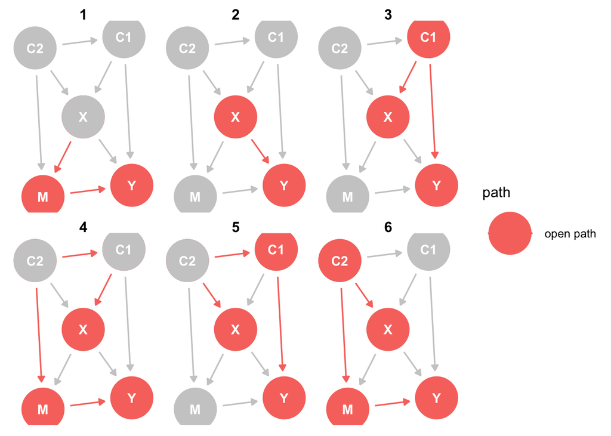

```r
library(ggdag)

# Define the DAG
dag <- dagify(
  C1 ~ C2,
  X ~ C1 + C2,
  M ~ C2 + X,
  Y ~ C1 + X + M,
  exposure = "X",
  outcome = "Y"
)

# Find all paths from X to Y
ggdag_paths(dag, from = "X", to = "Y") +
  theme_dag()
```

# Adjustment Sets

## What is an Adjustment Set?

An **adjustment set** is a set of variables that, if we condition on them (control for them), will:

1. Close all backdoor paths from X to Y
2. Not open any new biasing paths

**In other words:** Variables that give us the causal effect when we include them in a regression

## Finding Adjustment Sets

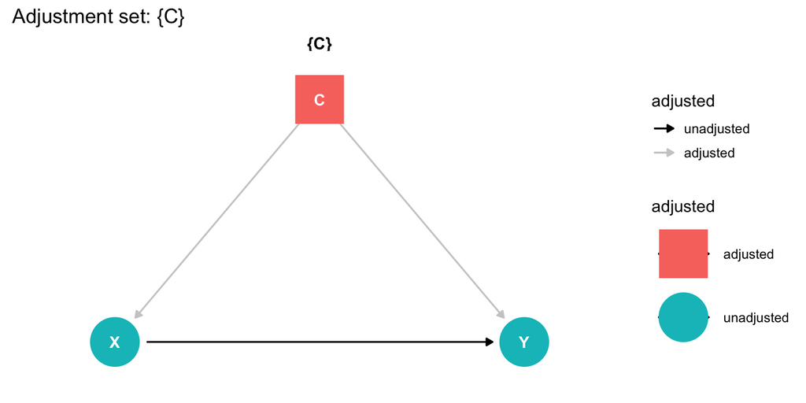

For this simple DAG, we need to adjust for **C**

## Using ggdag + dagitty to Find Adjustment Sets

```r
library(dagitty)

# Simple confounder DAG
simple_dag <- dagify(
  X ~ C,
  Y ~ C + X,
  exposure = "X",
  outcome = "Y"
)
# Find adjustment sets
adjustmentSets(simple_dag, exposure = "X", outcome = "Y")
```

```
{ C }
```

**Result:** We need to adjust for C

## The Backdoor Criterion

A set of variables **satisfies the backdoor criterion** if:

1. No variable in the set is a descendant of X (not caused by X)
2. The set blocks all backdoor paths from X to Y

**Practical meaning:** These are valid adjustment sets

## Example: What NOT to Control For

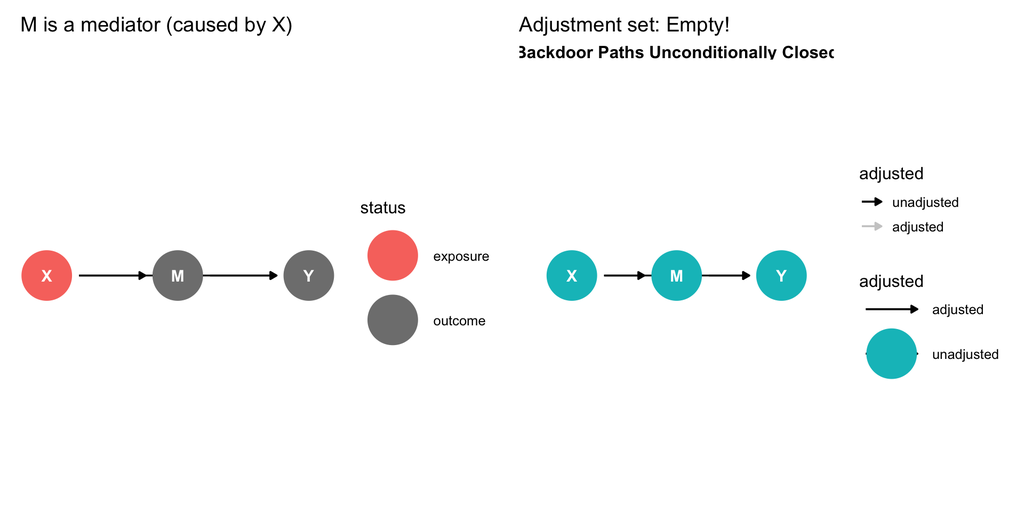

**Don’t control for mediators!** They’re part of the causal effect we want to measure

## Multiple Valid Adjustment Sets

```r
# More complex DAG
complex_dag <- dagify(
  X ~ C1 + C2,
  Y ~ C1 + C2 + C3 + X,
  C3 ~ C2,
  exposure = "X",
  outcome = "Y"
)

adjustmentSets(complex_dag, exposure = "X", outcome = "Y", type = "all")
```

```
{ C1, C2 }
{ C1, C2, C3 }
```

**Both work!** Usually we prefer smaller sets (fewer variables to measure)

## The Minimally Sufficient Adjustment Set

```r
# Same complex DAG
adjustmentSets(complex_dag, exposure = "X", outcome = "Y",
               type = "minimal")
```

```
{ C1, C2 }
```

**Minimal set:** The smallest set that closes all backdoor paths

## Visualizing Adjustment Sets

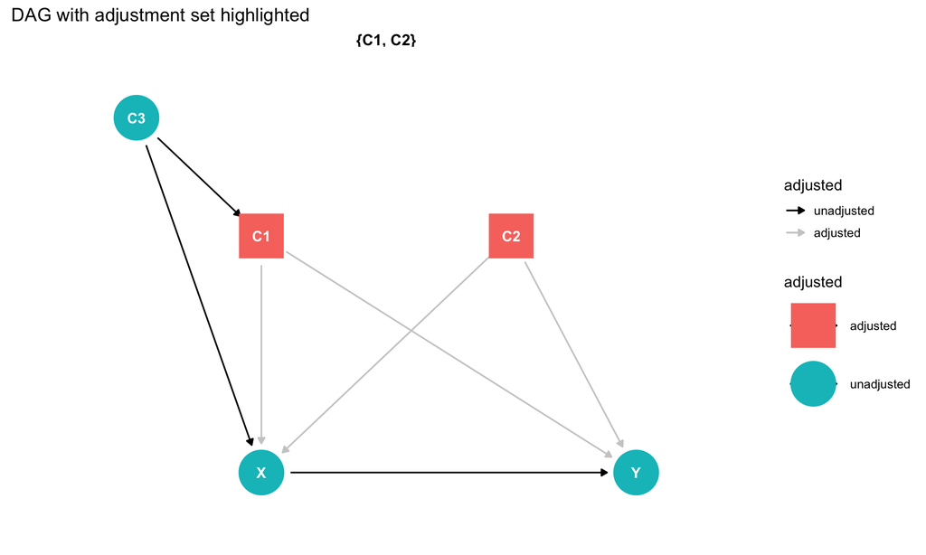

# From DAGs to Regression

## The Adjustment Formula

Once we identify an adjustment set Z, we can estimate the ATE:

$$E[Y(1) - Y(0)] =\\ E_Z[E[Y|X=1, Z] - E[Y|X=0, Z]]$$

# Proving the Adjustment Formula

## What We Want to Prove

**Goal:** Show that adjusting for confounders gives us the ATE

$$E[Y(1) - Y(0)] = E_Z[E[Y|X=1, Z] - E[Y|X=0, Z]]$$

**In words:** The average treatment effect equals the average difference in outcomes when we condition on the confounders

## Key Assumptions

**1. Conditional Exchangeability (No unmeasured confounding)**

$$Y(1), Y(0) \perp\!\!\!\perp X \mid Z$$

Given Z, exposure assignment is “as if random”

## Key Assumptions

**2. Positivity**

$$0 < P(X=1|Z) < 1 \text{ for all } Z$$

Everyone has some chance of being exposed and unexposed

## Key Assumptions

**3. Consistency**

$$Y = Y(1) \cdot X + Y(0) \cdot (1-X)$$

The outcome we observe equals the potential outcome under the exposure we received

## The Proof: Step 1

**Start with the definition of ATE:**

$$E[Y(1) - Y(0)] = E[Y(1)] - E[Y(0)]$$

**Focus on** $E[Y(1)]$ first (same logic applies to $E[Y(0)]$)

## The Proof: Step 2

**Use the law of iterated expectations:**

$$E[Y(1)] = E_Z[E[Y(1)|Z]]$$

## The Proof: Step 3

**Now use conditional exchangeability:**

$$E[Y(1)|Z] = E[Y(1)|X=1, Z]$$

**Why?** Because $Y(1) \perp\!\!\!\perp X \mid Z$

Given Z, the potential outcome $Y(1)$ is independent of whether you actually were exposed

**Intuition:** Among people with the same Z, those who were exposed are no different (in terms of potential outcomes) from those who weren’t

## The Proof: Step 4

**Use consistency:**

$$E[Y(1)|X=1, Z] = E[Y|X=1, Z]$$

**Why?** For people who actually were exposed ($X=1$), their observed outcome $Y$ equals their potential outcome under exposure $Y(1)$

**This is the crucial step:** We’ve gone from unobservable potential outcomes to observable actual outcomes!

## The Proof: Putting It Together

**Combining Steps 2-4:**

$$E[Y(1)] = E_Z[E[Y(1)|Z]]$$
$$= E_Z[E[Y(1)|X=1, Z]]$$
$$= E_Z[E[Y|X=1, Z]]$$

**By the same logic:**

$$E[Y(0)] = E_Z[E[Y|X=0, Z]]$$

## The Proof: Final Result

**Therefore:**

$$E[Y(1) - Y(0)] = E[Y(1)] - E[Y(0)]$$
$$= E_Z[E[Y|X=1, Z]] - E_Z[E[Y|X=0, Z]]$$
$$= E_Z[E[Y|X=1, Z] - E[Y|X=0, Z]]$$

# From Theory to Practice

## The Practical Question

**How do we actually compute** $E[Y|X, Z]$**?**

If Z is continuous or multidimensional, we can’t just stratify and take group means

## Some Approaches

**Parametric modeling:** Assume $E[Y|X, Z] = \beta_0 + \beta_1 X + \boldsymbol\beta^T \mathbf{Z}$ - Fit with linear regression - Use model to predict under $X=1$ and $X=0$

**Matching:** Pair treated and control units with similar Z values

**Weighting:** Reweight the sample to balance Z across treatment groups

## Simple Linear Regression Approach

**If we assume a linear model:**
$$Y = \beta_0 + \beta_1 X + \boldsymbol\beta^T \mathbf{Z} + \varepsilon$$

Under (strong!) conditions:
$$\hat{\beta}_1 = \text{Average Treatment Effect}$$

## Assumptions for Linear Regression = ATE

For $\hat{\beta}_1$ to equal the ATE, we need:

1. **Correct adjustment set:** Z satisfies the backdoor criterion
2. **No unmeasured confounding:** We measured all confounders
3. **Linearity:** Effects are additive (no interactions)
4. **Positivity:** Every unit has non-zero probability of both exposures

## Example: Simulated Data

```r
set.seed(1)
n <- 1000

# Confounder
C <- rnorm(n)

# Exposure (affected by confounder)
X <- rbinom(n, 1, plogis(0.5 * C))

# Outcome (true ATE = 2)
Y <- 2 * X + 3 * C + rnorm(n)
```

## Naive Regression (Confounded)

```r
# Without adjusting for C
naive_model <- lm(Y ~ X)
coef(naive_model)["X"]
```

```
      X
3.70334
```

**Wrong!** This is biased because C affects both X and Y

## Adjusted Regression (Correct)

```r
# Adjusting for C
adjusted_model <- lm(Y ~ X + C)
coef(adjusted_model)["X"]
```

```
       X
2.029299
```

**Correct!** This recovers the true ATE of 2 (plus sampling error)

## Why This Works: FWL Perspective

Remember the Frisch-Waugh-Lovell theorem?

When we regress Y ~ X + C, the coefficient on X is:

**The relationship between the part of Y that C can’t explain and the part of X that C can’t explain**

This is exactly what we want! We’ve removed C’s confounding influence

## Visualizing the Adjustment

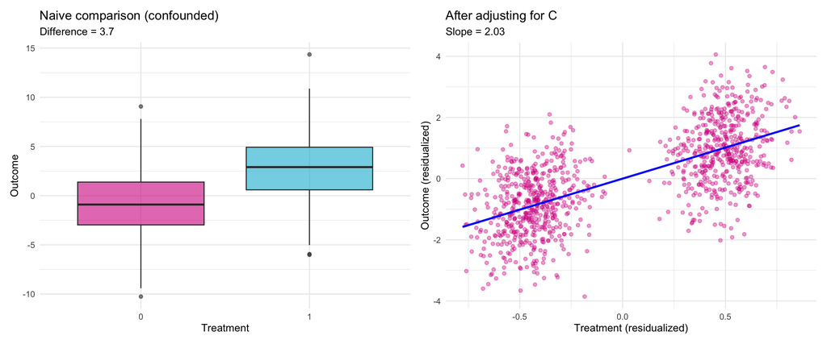

# G-Computation for Linear Regression

## What is G-Computation?

**G-computation** is a method to estimate causal effects by:

1. Fitting a model for the outcome
2. Predicting outcomes under different treatment values
3. Averaging these predictions

## The G-Computation Formula

Recall the adjustment formula:
$$E[Y(1)] = E_Z[E[Y|X=1, Z]]$$

## The G-Computation Formula

**G-computation procedure:**

1. Fit $E[Y|X, Z]$ (our outcome model)
2. For each unit, predict $\hat{Y}_i(1)$ setting $X=1$, using their $Z_i$
3. Average: $\frac{1}{n}\sum_i \hat{Y}_i(1)$
4. Repeat for $X=0$ to get $\hat{E}[Y(0)]$
5. ATE = $\hat{E}[Y(1)] - \hat{E}[Y(0)]$

## Why Bother with G-Computation?

**For simple linear models with no interactions:** The regression coefficient equals the ATE

**G-computation becomes useful when:**

- You have interactions between treatment and covariates
- You have non-linear models
- You want to estimate effects on different scales

## G-Computation: Step by Step

```r
# Use our previous example data
set.seed(1)
n <- 1000
C <- rnorm(n, 1)
X <- rbinom(n, 1, plogis(0.5 * C))
Y <- 2 * X + 3 * C + rnorm(n)
data_all <- data.frame(X = X, C = C, Y = Y)

# Step 1: Fit the outcome model
outcome_model <- lm(Y ~ X + C, data_all)
```

## G-Computation: Step 2-3

```r
# Step 2: Create datasets with everyone treated and untreated

# Everyone treated (X = 1)
data_treated <- data_all
data_treated$X <- 1

# Everyone untreated (X = 0)
data_control <- data_all
data_control$X <- 0
```

## G-Computation: Step 4-5

```r
# Step 3: Predict outcomes under both scenarios
Y1_pred <- predict(outcome_model, newdata = data_treated)
Y0_pred <- predict(outcome_model, newdata = data_control)

# Step 4: Average predictions
E_Y1 <- mean(Y1_pred)
E_Y0 <- mean(Y0_pred)

# Step 5: Compute ATE
ATE_gcomp <- E_Y1 - E_Y0
ATE_gcomp
```

```
[1] 2.025261
```

**Same as the regression coefficient!** (for linear models with no interactions)

## When G-Computation Differs: Interactions

```r
set.seed(1)
n <- 1000
C <- rnorm(n, 1)
X <- rbinom(n, 1, plogis(0.25 * C))

# Treatment effect varies by C! (interaction)
Y_interact <- 2 * X + 3 * C + 1.5 * X * C + rnorm(n)
```

**Now the treatment effect is not constant:**

- When C = 0, effect is 2
- When C = 1, effect is 2 + 1.5 = 3.5

## Interaction Model: Regression Approach

```r
# Fit model with interaction
interact_model <- lm(Y_interact ~ X + C + X:C)
coef(interact_model)
```

```
(Intercept)           X           C         X:C
-0.09771085  2.14169352  3.04054859  1.44840785
```

**Question:** What’s the average treatment effect?

**Problem:** The coefficient on X (2.14) is the effect when C = 0, not the average!

## Interaction Model: G-Computation

```r
# Create counterfactual datasets
data_all_int <- data.frame(X = X, C = C, Y = Y_interact)
data_treated_int <- data_all_int
data_treated_int$X <- 1
data_control_int <- data_all_int
data_control_int$X <- 0

# Predict and average
Y1_pred_int <- predict(interact_model, newdata = data_treated_int)
Y0_pred_int <- predict(interact_model, newdata = data_control_int)

ATE_gcomp_int <- mean(Y1_pred_int) - mean(Y0_pred_int)
ATE_gcomp_int
```

```
[1] 3.57323
```

**G-computation gives us the average effect across the distribution of C!**

## Why G-Computation Works Here

**The average treatment effect is:** $\text{ATE} = E[2 + 1.5 \times C]$

Since $E[C] \approx 1$, the ATE $\approx 3.5$

**G-computation automatically:**

1. Computes effect for each value of C
2. Averages using the actual distribution of C

**Regression coefficient:** Only gives effect at C = 0

## Visualizing Heterogeneous Effects

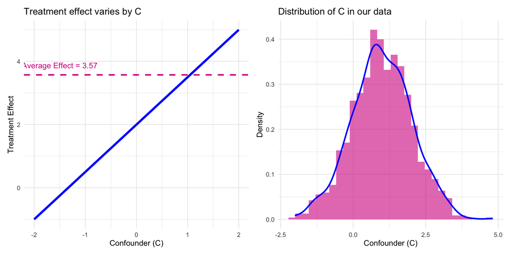

**G-computation averages the blue line using the distribution on the right**

## G-Computation Algorithm Summary

**For any outcome model:**

1. Fit model: $E[Y|X, Z]$
2. Create $n$ copies of data with $X = 1$
3. Predict: $\hat{Y}_i(1)$ for each unit
4. Create $n$ copies of data with $X = 0$
5. Predict: $\hat{Y}_i(0)$ for each unit
6. Compute: $\hat{\text{ATE}} = \frac{1}{n}\sum_i[\hat{Y}_i(1) - \hat{Y}_i(0)]$

# Putting It All Together

## The Complete Workflow

**Step 1: Draw the DAG**

- List all relevant variables
- Draw arrows based on domain knowledge
- Identify treatment (X) and outcome (Y)

## The Complete Workflow

**Step 2: Identify adjustment set**

- Find all backdoor paths
- Determine minimal sufficient adjustment set
- Check for colliders (don’t adjust!)

## The Complete Workflow

**Step 3: Collect data**

- Measure treatment, outcome, and adjustment set
- More data is better (reduces sampling variability)

**Step 4: Fit the model**

- Start with linear regression: Y ~ X + Z
- Consider interactions if theory suggests heterogeneity

## The Complete Workflow

**Step 5: Estimate the ATE**

- Simple model: Use coefficient
- Complex model: Use G-computation

## Key Assumptions to Remember

**1. No unmeasured confounding**

- We measured all confounders
- Requires domain knowledge

**2. Positivity**

- Everyone has some chance of treatment and control
- Check for overlap in covariate distributions

**3. Correct model specification**

- For linear regression: linearity, include important interactions

## Common Pitfalls

**❌ Controlling for colliders**

Creates bias where there was none!

**❌ Not controlling for confounders**

Leads to biased estimates

**❌ Controlling for mediators**

Blocks the causal effect you want to measure

**❌ Interpreting regression coefficients as causal without thinking about the DAG**

Correlation ≠ causation!

## Tips for Success

**✓ Start with the DAG**

Think causally before looking at data

**✓ Use domain knowledge**

Statistics can’t tell you what causes what

**✓ Be transparent about assumptions**

No unmeasured confounding is a strong assumption

**✓ Consider sensitivity analyses**

What if there’s an unmeasured confounder?

# Sensitivity to Unmeasured Confounding

## The Problem

**What if we missed a confounder?**

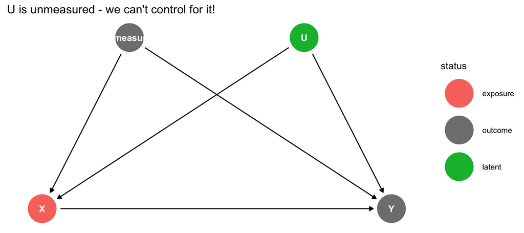

Our estimate will be biased if U affects both X and Y

## Omitted Variable Bias Formula

**What we estimate when U is unmeasured:**

$$\hat{\beta}_X = \beta_X + \beta_U \times \delta_{UX}$$

## Example: Exercise and Heart Health

```r
set.seed(1)
n <- 1000

# Unmeasured confounder: genetic fitness
genetic_fitness <- rnorm(n)

# Measured confounder: age
age <- rnorm(n, mean = 50, sd = 10)

# Exercise depends on both age and genetics
exercise_hours <- 5 + (-0.08 * age) + 0.6 * genetic_fitness + rnorm(n, sd = 1)
exercise_hours <- pmax(exercise_hours, 0)  # Can't be negative

# Heart health depends on exercise AND genetics
# True effect of exercise = -2 (negative = better)
heart_disease_risk <- 60 + (-2 * exercise_hours) +
                      0.3 * age + (-3 * genetic_fitness) + rnorm(n, sd = 3)
```

## Naive Estimate (No Controls)

```r
# No controls
naive <- lm(heart_disease_risk ~ exercise_hours)
coef(naive)["exercise_hours"]
```

```
exercise_hours
     -4.503693
```

## Controlling for Measured Confounder

```r
# Control for age only
partial_control <- lm(heart_disease_risk ~ exercise_hours + age)
coef(partial_control)["exercise_hours"]
```

```
exercise_hours
     -3.518357
```

**Still biased!** We adjusted for age, but genetic fitness remains unmeasured

## Oracle Estimate (If We Could Measure Everything)

```r
# Control for both (hypothetical - we can't measure genetics)
full_control <- lm(heart_disease_risk ~ exercise_hours + age + genetic_fitness)
coef(full_control)["exercise_hours"]
```

```
exercise_hours
     -2.008628
```

**Unbiased:** Recovers the true effect of -2 (plus sampling error)

## Computing the Bias Using FWL

```r
# Our estimate from partial control
beta_x_biased <- coef(partial_control)["exercise_hours"]

# Regress outcome on unmeasured U (controlling for measured)
beta_u <- coef(lm(heart_disease_risk ~ genetic_fitness + age))["genetic_fitness"]

# Regress treatment on unmeasured U (controlling for measured)
delta_ux <- coef(lm(exercise_hours ~ genetic_fitness + age))["genetic_fitness"]

# Predicted bias
predicted_bias <- beta_u * delta_ux
predicted_bias
```

```
genetic_fitness
      -1.884238
```

## Predicted vs. Actual Bias

```r
# Actual bias
true_effect <- -2
actual_bias <- beta_x_biased - true_effect

data.frame(
  actual_bias = actual_bias,
  predicted_bias = predicted_bias
)
```

```
               actual_bias predicted_bias
exercise_hours   -1.518357      -1.884238
```